# Actividad

- Regina Rodriguez Sanchez - a01284329
- Emilio De Gyves García - a01351989
- Emilio Rizo De la Mora - a01721612

# Entregar

Archivo PDF de la actividad y la liga de la actividad en su repostitorio.

# Nota:

Esta actividad se evaluará de acuerdo a la rúbrica en Canvas.

Al integrante que no participe en la actividad no se le tomará en cuenta para la calificación.

El límite para entregar las actividades es el viernes antes de las 23:59.

# Importante:

- Colocar nombre en ejes en gráficas
- Nombre en gráficas
- Conclusiones con el nombre de cada alumno
- Contestar cada pregunta

**Gastos en seguro**

Nuestro objetivo será construir un modelo que nos permita estimar los gastos de seguro dependiendo de edad,sexo, indice de masa corporal, numero de hijos, si se fuma, región.

El dataset consta de las columnas:

- age: edad del beneficiario principal
- sex: female o male
- bmi: indice de masa corporal
- children: numero de niños que estan cubiertos con la poliza.
- smoke: si fuma el beneficiario si/no
- region: región en dónde vive el beneficiario. Estos datos son de Estados Unidos. Regiones disponibles: northeast, southeast, southwest, northwest
- charges: costo del seguro.

Referencia de dataset: https://github.com/stedy/Machine-Learning-with-R-datasets/blob/master/insurance.csv

1.a. Carga los datos del archivo insurance.csv

```python
from google.colab import drive
drive.mount('/content/drive/')
%cd 'drive/MyDrive/SemanaTec/arte-analitica'
import pandas as pd
import numpy as np
import seaborn as sns


books = pd.read_csv('data/insurance.csv')
```

1.b. Crea unas columnas con las siguientes caracteristicas:

- fuma: 1 si el bvalor de smoke es "yes" y 0 si el valor de smoke es "no"
- region: si es northeast - 0 , southeast- 1, southwest- 2, northwest - 3
- sexo: 0 si es "male" y 1 si es "female"

```python
books['smoker']  = books['smoker'].map(dict(yes=1, no=0))
books['region'] = books['region'].map(dict(northeast=0, southeast=1, southwest=2, northwest=3))
books['sex'] = books['sex'].map(dict(female=1, male=0))
books.head()
```

|  | age | sex | bmi | children | smoker | region | charges |
| --- | --- | --- | --- | --- | --- | --- | --- |
| 0 | 19 | 1 | 27.900 | 0 | 1 | 2 | 16884.92400 |
| 1 | 18 | 0 | 33.770 | 1 | 0 | 1 | 1725.55230 |
| 2 | 28 | 0 | 33.000 | 3 | 0 | 1 | 4449.46200 |
| 3 | 33 | 0 | 22.705 | 0 | 0 | 3 | 21984.47061 |
| 4 | 32 | 0 | 28.880 | 0 | 0 | 3 | 3866.85520 |

1. Generar una(s) grafica(s) para visuaizar cómo se relaciona cada columna de costo en seguro contra otras variables.

|  | age | sex | bmi | children | smoker | region | charges |
| --- | --- | --- | --- | --- | --- | --- | --- |
| age | 1.000000 | 0.020856 | 0.109272 | 0.042469 | -0.025019 | 0.002613 | 0.299008 |
| sex | 0.020856 | 1.000000 | -0.046371 | -0.017163 | -0.076185 | 0.009346 | -0.057292 |
| bmi | 0.109272 | -0.046371 | 1.000000 | 0.012759 | 0.003750 | -0.054428 | 0.198341 |
| children | 0.042469 | -0.017163 | 0.012759 | 1.000000 | 0.007673 | 0.036617 | 0.067998 |
| smoker | -0.025019 | -0.076185 | 0.003750 | 0.007673 | 1.000000 | -0.044124 | 0.787251 |
| region | 0.002613 | 0.009346 | -0.054428 | 0.036617 | -0.044124 | 1.000000 | -0.050226 |
| charges | 0.299008 | -0.057292 | 0.198341 | 0.067998 | 0.787251 | -0.050226 | 1.000000 |

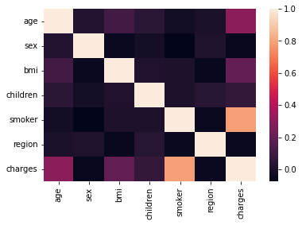

```python
books_corr = books.corr()
sns.heatmap(data=books_corr)
books.corr()
```

1. ¿ Qué conclusiones puedes obtener de las graficas anteriores?

```python
#R= A partir de los resultados de las graficas anteriores la variable con la que mas correlacion
#tiene la variable "charges" es con la de "smoker" con las demas variables tienen muy poca relacion entre si
```

1. **Regresión lineal**. En su forma más simple, consiste en asumir que una variable $x$ y una variable $y$ presentan una relación lineal de la forma:

$$ y \approx \beta_0 + \beta_1 \cdot x$$

¿Cuál es el valor de beta_0 , beta_1 y el Score para **Edad vs Costo** , **Indice de masa corporal vs Costo** , **Niños vs Costo** y otros?

```python
from sklearn.linear_model import LinearRegression
# Edad vs Costo
model1 = LinearRegression()
model1.fit(books[['age']], books['charges'])
print("Age Vs Charges")
print("Beta_0: ",model1.intercept_)
print("Beta_1: ",model1.coef_)
print("Score: ", model1.score(books[['age']],books['charges']), "\n")

# Indice de masa corporal vs Costo
model2 = LinearRegression()
model2.fit(books[['bmi']], books['charges'])
print("BMI Vs Charges")
print("Beta_0: ",model2.intercept_)
print("Beta_1: ",model2.coef_)
print("Score: ", model2.score(books[['bmi']],books['charges']), "\n")

# Niños vs Costo
model3 = LinearRegression()
model3.fit(books[['children']], books['charges'])
print("Children Vs Charges")
print("Beta_0: ",model3.intercept_)
print("Beta_1: ",model3.coef_)
print("Score: ", model3.score(books[['children']],books['charges']), "\n")
```

```
Age Vs Charges
Beta_0:  3165.885006063021
Beta_1:  [257.72261867]
Score:  0.08940589967885804

BMI Vs Charges
Beta_0:  1192.9372089611497
Beta_1:  [393.8730308]
Score:  0.03933913991786264

Children Vs Charges
Beta_0:  12522.495549644098
Beta_1:  [683.08938248]
Score:  0.004623758854459203
```

1. ¿Cuál de los modelos es mejor de acuerdo al score ordenalos del mejor al peor?

1. **Regresión lineal múltiple**. Como ahora vamos a incluir más de una variable, el modelo se rescribe a :

$$ \hat{y} = \hat{\beta}_0 + \hat{\beta}_1 \cdot x_1 + \hat{\beta}_2 \cdot x_2 + \hat{\beta}_3\cdot x_3 + \ldots \epsilon $$

Elige las diferentes combinaciones de variables. Ejemplo: Redes y Youtube vs Ventas

```python
lm1 = LinearRegression()
# La variable X la ponemos con doble corchete!
lm1.fit(books[['age', 'children','region']], books['charges'])
print('Age, Niños, and Region')
print('beta_0: ', lm1.intercept_)
print('betas: ', lm1.coef_)
print('Score: ', lm1.score(books[['age', 'children','region']], books['charges']), '\n')


#Lm2 Niños,Region,BMI and charges

lm2 = LinearRegression()
lm2.fit(books[['bmi', 'children','region']], books['charges'])
print('BMI, Niños, and Region')
print('beta_0: ', lm2.intercept_)
print('betas: ', lm2.coef_)
print('Score: ', lm2.score(books[['bmi', 'children','region']], books['charges']), '\n')

#Lm3 BMI, Smoker, Age and charges
lm3 = LinearRegression()
lm3.fit(books[['bmi', 'smoker','age']], books['charges'])
print('BMI, Fumador, and Age')
print('beta_0: ', lm3.intercept_)
print('betas: ', lm3.coef_)
print('Score: ', lm3.score(books[['bmi', 'smoker','age']], books['charges']), '\n')


#Lm4 AGE,SMOKER, REGION and charges
lm4 = LinearRegression()
lm4.fit(books[['age', 'smoker','region']], books['charges'])
print('EDAD, Fumador, and Region')
print('beta_0: ', lm4.intercept_)
print('betas: ', lm4.coef_)
print('Score: ', lm4.score(books[['age', 'smoker','region']], books['charges']), '\n')

#LM5 REGION,NIÑOS,Sex and charges

lm5 = LinearRegression()
lm5.fit(books[['region', 'children','sex']], books['charges'])
print('REGION, NIÑOS, and Sex')
print('beta_0: ', lm5.intercept_)
print('betas: ', lm5.coef_)
print('Score: ', lm5.score(books[['region', 'children','sex']], books['charges']), '\n')
```

```
Age, Niños, and Region
beta_0:  3477.9425852574423
betas:  [ 255.74320281  576.03582763 -581.99464652]
Score:  0.09528541418900904

BMI, Niños, and Region
beta_0:  1332.1702030704764
betas:  [ 387.62846796  673.54095788 -460.95106427]
Score:  0.04538694017480793

BMI, Fumador, and Age
beta_0:  -11676.830425187763
betas:  [  322.61513282 23823.68449531   259.54749155]
Score:  0.7474771588119513

EDAD, Fumador, and Region
beta_0:  -2127.3923447437264
betas:  [  274.89200764 23834.14229849  -175.3840475 ]
Score:  0.7216563908925873

REGION, NIÑOS, and Sex
beta_0:  14029.253931057001
betas:  [ -572.46196056   692.7124342  -1346.69734976]
Score:  0.01049888229004281
```

1. ¿Cuál modelo es el que nos conviene elegir?

R = el de BMI, Smoker and Age

1. Conclusiones

Emilio Rizo A01721612: Es muy interesante como la libreria puede ser muy util para ecuaciones y funciones matematicas como puede ser la regresión lineal y multiple. Fue muy interesante implementarlo nosotros a el csv file que tuvimos que manipular. Nos puede ser de mucha ayuda en un futuro y realmente puede ahorrarte mucho tiempo. Los dataframes con los que trabajamos fueron muy utiles y me gusto mucho aprender como utilizarlos y modificarlos. Fue un proyecto muy interesante que me ayudo a fortalecer mis herramientas para programar.

Emilio De Gyves A01351989:  
La analítica es un área muy útil para estos días, es necesaria para muchos trabajos y avances, en este proyecto pudimos observar una de sus aplicaciones en el mundo laboral, respecto a la actividad, gracias a la grafica pudimos observar que la mayor correlación la tuvieron entre los costos y los fumadores, graficar fue muy útil ya que lo pudimos ver de una manera muy visual, nos costó un poco de trabajo la parte de regresión lineal y la regresión lineal múltiple pero nos sirvió el trabajar en equipo ya que gracias a eso pudimos resolverlo y encontrar el modo.

Regina Rodriguez A01284329: Al terminar esta semana tec aprendi muchas funcionalidades nuevas y hacer un mejor uso de la tecnologia que tenemos a nuestro alcance, como conectar github con google drive y a combinar la estadistica con la programacion. Este proyecto me ayudo s observar todo lo que poemos hacer con las librerias de panda y las librerias de graficos para poder tener mejores predicciones o ver que variables pueden afectar algo como los costos de seguro. Como equipo nos entendimos muy bien y creo que hicimos un buen trabajo en conjunto.

# Guardar el resultado como pdf

- Exporta el notebook a formato HTML.

```python
! jupyter nbconvert --to HTML '/content/drive/MyDrive/SemanaTec/arte-analitica/6.3 - Actividad Regresion Linea.ipynb'
```

[output not shown]

[output cut: 107 more lines]

[output not shown]

- Haz doble clic en el archivo nuevo que se creó dentro de la carpeta `arte-analitica` y en la parte superior derecha dale clic en **imprimir**
- Imprime el archivo como *PDF* y súbelo a Canvas.